# Eksplorasi Data Saham

Rasyid Ridha

## Pembukaan

Sejak tahun 2012 saat pertama kali saya membuka rekening bank, saya menyimpan tabungan di bank sehingga tergerus dengan kencangnya arus inflasi. Dari awal saya mendapatkan penghasilan, yaitu tahun 2016, saya sebaiknya menerapkan strategi finansial yang tepat untuk menjaga *net worth* saya agar tidak tergerus inflasi. Baru-baru ini, saya mulai melek finansial dan mencoba untuk mempelajari pasar modal agar setidaknya bisa menahan laju inflasi.

Terlebih dahulu, kita akan mengambil data inflasi tahunan Indonesia dari tahun 2008 hingga 2018.

```r
if (file.exists("data/inflasi_2008_2018.rds")) {
  infl <- read_rds("data/inflasi_2008_2018.rds")
} else {
  infl <- tq_get("IDNCPIALLAINMEI", "economic.data", from = "2008-01-01", to = "2019-12-31")
  # infl <- tq_get("IDNCPIALLMINMEI", "economic.data", from = "1970-01-01", to = "2019-12-31")
  write_rds(infl, "data/inflasi_2008_2018.rds")
}
```

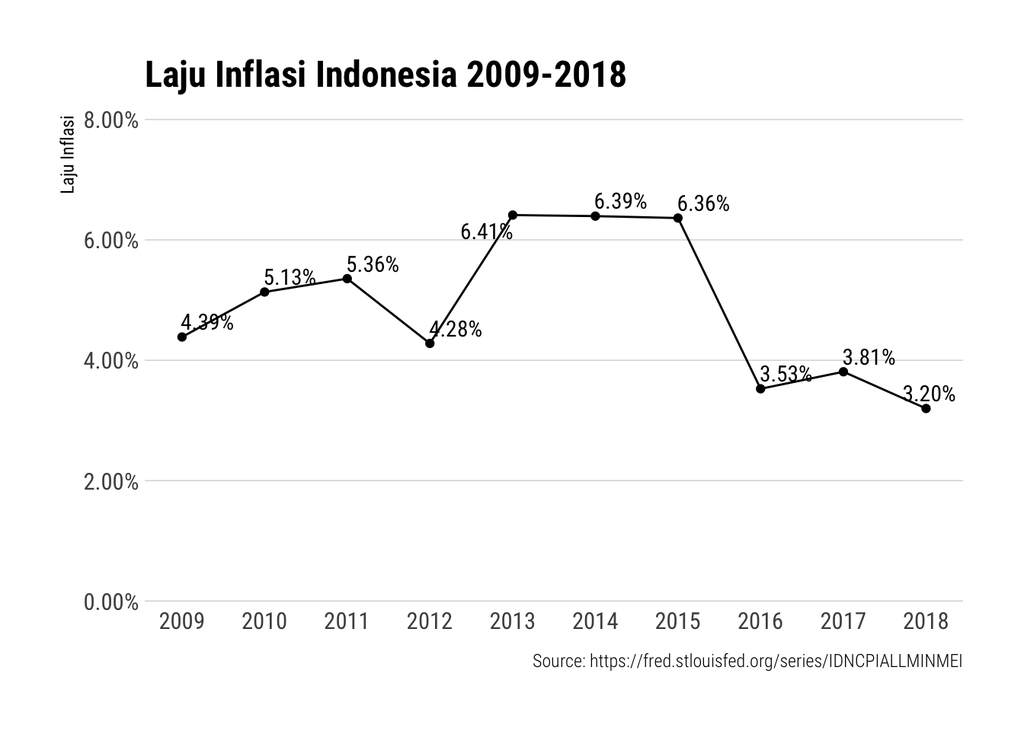

```r
infl %>%
  filter(year(date) >= 2008) %>%
  mutate(growth = (price - lag(price)) / lag(price)) %>%
  filter(!is.na(growth)) %>%
  ggplot(aes(date, growth)) +
  geom_line() +
  geom_point() +
  theme_ipsum_rc(grid = "Y") +
  labs(x = NULL, y = "Laju Inflasi",
       title = "Laju Inflasi Indonesia 2009-2018",
       caption = "Source: https://fred.stlouisfed.org/series/IDNCPIALLMINMEI") +
  scale_y_percent(limits = c(0,0.08)) +
  scale_x_date(date_breaks = "year",
               date_labels = "%Y") +
  ggrepel::geom_text_repel(aes(label = scales::percent(growth)),
                           family = "Roboto Condensed")
```

Beberapa istilah-istilah dalam pasar modal yang mungkin perlu saya garisbawahi adalah:

- *Bearish*: pergerakan harga saham dalam jangka waktu tertentu yang cenderung menurun/downtrend
- *Bullish*: pergerakan harga saham dalam jangka waktu tertentu yang cenderung meningkat/uptrend
- *Closing price*: harga penutupan dari suatu harga saham di bursa
- *Earning Per Share (EPS)*: laba bersih per saham perusahaan

Referensi untuk pemula:

- Nabung Saham 2019 ([Part 1](https://www.youtube.com/watch?v=93OqbLazMzg), [Part 2](https://www.youtube.com/watch?v=6Z7N24a_nLo), [Lainnya](https://www.youtube.com/watch?v=lJIDJEXzo34&list=PLjPXuypTt-5uRS46yD3qyIgcZCxNZk1cZ))

  Kriteria saham untuk investasi jangka panjang (5-10 tahun): ROE >15%, kapitalisasi pasar >20T, sektor defensif (makanan, gaya hidup, perbankan, telekomunikasi). Saham-saham yang memenuhi kriteria berdasarkan tautan tersebut: GGRM, BBCA, ICBP, BBNI, BBRI, MYOR, JPFA, ACES. Pembelian rutin di awal bulan atau akhir bulan, penjualan ketika MA100 crossing ke bawah MA200.

## Persiapan Data

Terlebih dahulu, kita akan mengambil data saham pilihan dari tahun 2008-2018

```r
# mengambil saham telkom, bca, unilever dan gudang garam
if (file.exists("data/saham_top_20080101_20181231.rds")) {
  ptf <- read_rds("data/saham_top_20080101_20181231.rds")
} else {
  ptf <- tibble(stocks = c("BBCA.JK", "TLKM.JK", "UNVR.JK", "GGRM.JK", "ICBP.JK",
                           "BBNI.JK", "BBRI.JK", "MYOR.JK", "JPFA.JK", "ACES.JK"),
       industry = c("Perbankan", "Telekomunikasi", "Makanan", "Rokok", "Makanan",
                    "Perbankan", "Perbankan", "Makanan", "Makanan", "Lainnya")) %>%
  tq_get(get = c("stock.prices", "dividends"), from = "2008-01-01", to = "2018-12-31")
  write_rds(ptf, "data/saham_top_20080101_20181231.rds")
}

# GROWTH AVG
ptf <- ptf %>%
  bind_cols(ptf %>%
              select(-dividends) %>%
              unnest() %>%
              filter(date %in% c(ymd(20080102), ymd(20180101))) %>%
              group_by(stocks) %>%
              mutate(price = ifelse(date == ymd(20080102), high, low),
                     growth = (price - lag(price)) / lag(price) - 1,
                     growth_cagr = (price/lag(price))^(1 / (-year(lag(date))+year(date)+1) ) - 1 ) %>%
              filter(!is.na(growth)) %>%
              ungroup() %>%
              select(growth, growth_cagr)) %>%
  left_join(ptf %>%
              select(-dividends) %>%
              unnest() %>%
              group_by(stocks, year = year(date)) %>%
              summarise(price = mean(close, na.rm = TRUE)) %>%
              ungroup() %>%
              group_by(stocks) %>%
              mutate(growth = (price - lag(price)) / lag(price)) %>%
              group_by(stocks) %>%
              summarise(growth_yearly_avg = mean(growth, na.rm = TRUE)))
```

## Visualisasi Data

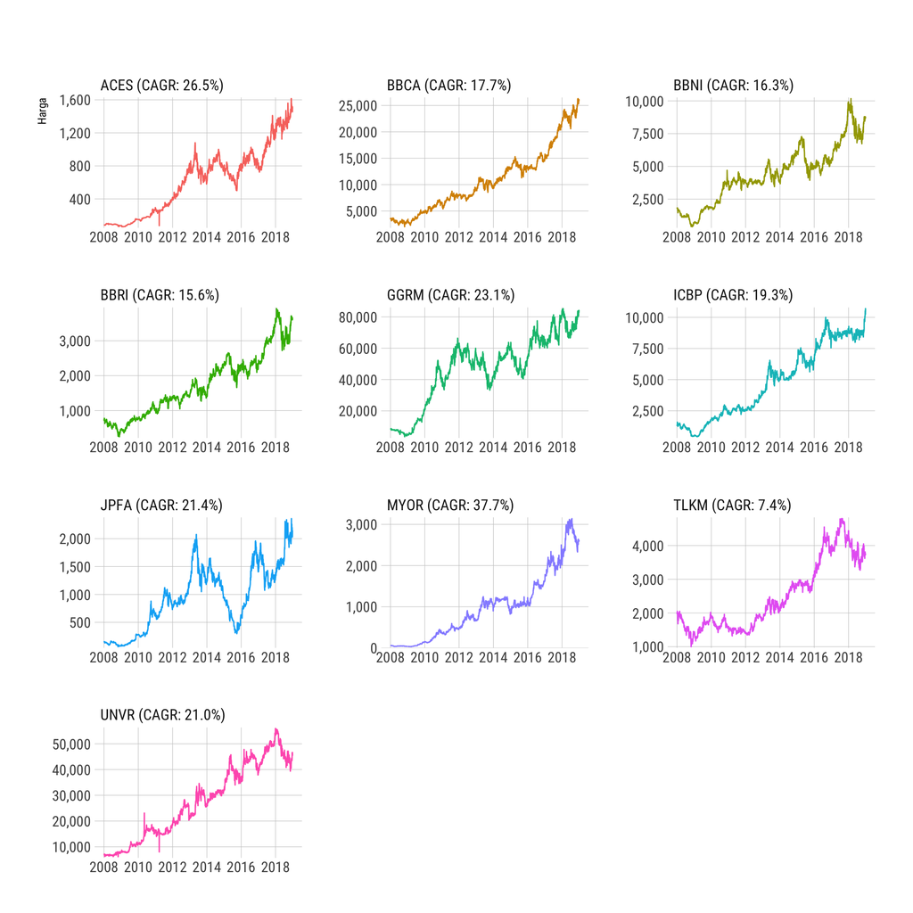

```r
ptf %>%
  mutate(stocks = paste0(stocks, " (CAGR: ", scales::percent(growth_cagr), ")")) %>%
  select(-dividends) %>%
  unnest() %>%
  mutate(stocks = gsub("\\.JK", "", stocks)) %>%
  group_by(stocks) %>%
  mutate(price = close) %>%
  ggplot(aes(date, price, color = stocks)) +
  geom_line() +
  theme_ipsum_rc(grid = "XY") +
  facet_wrap(.~stocks, scales = "free", ncol = 3) +
  scale_y_comma() +
  guides(color = FALSE) +
  labs(x = NULL, y = "Harga",
       title = "")
```

## Simulasi DCA

DCA (**dollar cost averaging**) merupakan salah satu metode investasi yang cukup populer. Di sini, saya akan melakukan simulasi DCA sederhana yaitu dengan cara membeli saham secara rutin per bulan dengan konfigurasi berikut:

- Bulan pembelian pertama: **Januari 2010**
- Bulan pembelian terakhir: **Desember 2018**
- Durasi: **9 tahun**
- Tanggal penjualan: **31 Desember 2018**
- Budget investasi per bulan: **2 juta rupiah**
- Diversifikasi: **TLKM, ACES, JPFA, MYOR**
- Fee beli: **0.15%** dan fee jual: **0.25%**

```r
# config
year_start <- 2010
year_end <- 2018
fee_buy <- 0.15 * 1/100
fee_sell <- 0.25 * 1/100
stock_list <- c("MYOR.JK", "JPFA.JK", "TLKM.JK", "ACES.JK")
monthly_budget <- 2000000

# calculation
ptf_sell <- ptf %>%
  select(stocks, industry, stock.prices) %>%
  unnest() %>%
  group_by(stocks) %>%
  filter(date == max(date)) %>%
  select(stocks, price = low) %>%
  ungroup() %>%
  mutate(price_100 = price * 100)
ptf_buy_dca <- ptf %>%
  select(stocks, industry, stock.prices) %>%
  unnest() %>%
  mutate(my = format(date, "%Y%m"),
        y = year(date)) %>%
  group_by(stocks, my) %>%
  filter(date == min(date)) %>%
  mutate(price = high) %>%
  filter(stocks %in% stock_list,
         y >= year_start) %>%
  select(stocks, industry, date, price) %>%
  arrange(my, stocks) %>%
  mutate(share_min = 100,
         budget = monthly_budget) %>%
  mutate(price_100 = share_min * price) %>%
  group_by(my) %>%
  mutate(price_all = sum(price),
         price_all_100 = sum(price_100),
         budget_rest = budget - price_all_100,
         lot_add = round(budget_rest %/% price_all_100)) %>%
  ungroup() %>%
  mutate(lot_sum = share_min/100 + lot_add,
         price_sum = lot_sum * price_100)
ptf_buy_dca_smr <- ptf_buy_dca %>%
  group_by(stocks) %>%
  summarise(lot_sum = sum(lot_sum),
            price_sum = sum(price_sum))
ptf_buy_dca_smr <- ptf_buy_dca_smr %>%
  inner_join(ptf_sell) %>%
  mutate(price_sell = price_100 * lot_sum,
         growth = (price_sell - price_sum) / price_sum) %>%
  bind_rows(ptf_buy_dca_smr %>%
              inner_join(ptf_sell) %>%
              mutate(stocks = "ALL",
                     price_sell = price_100 * lot_sum) %>%
              group_by(stocks) %>%
              summarise_if(is.numeric, funs(sum)) %>%
              ungroup() %>%
              mutate(growth = (price_sell - price_sum) / price_sum)) %>%
  mutate(price_sum_real = price_sum * (1+fee_buy),
         price_sell_real = price_sell * (1-fee_sell),
         growth_real = (price_sell_real - price_sum_real) / price_sum_real,
         growth_real_cagr = (price_sell_real / price_sum_real)^(1/(year_end-year_start+1)) - 1  ) %>%
  mutate(stocks = gsub("\\.JK", "", stocks)) %>%
  select(-price, -price_100)
```

```r
ptf_buy_dca_div <- ptf_buy_dca %>%
  arrange(stocks, my) %>%
  group_by(stocks) %>%
  mutate(lot_cumulative = cumsum(lot_sum)) %>%
  ungroup() %>%
  left_join(ptf %>%
              select(stocks, dividends) %>%
              unnest() %>%
              mutate(my = format(date, "%Y%m")) %>%
              rename(date_dividend = date) %>%
              arrange(stocks, dividends, date_dividend) %>%
              group_by(my, stocks) %>%
              filter(row_number() == 1) %>%
              ungroup()) %>%
  mutate(dividend_ratio = dividends / price,
         dividend_total = ifelse(date_dividend > date,
                                 lot_cumulative * dividends * 100,
                                 (lot_cumulative - lot_sum) * dividends * 100)) %>%
  group_by(stocks) %>%
  summarise(divident_cnt = n_distinct(date_dividend, na.rm = TRUE),
            dividend_total = sum(dividend_total, na.rm = TRUE),
            divident_net = dividend_total * 0.9) %>%
  ungroup()
ptf_buy_dca_div <- ptf_buy_dca_div %>%
  bind_rows(ptf_buy_dca_div %>%
              group_by(stocks = "ALL") %>%
              summarise_all(sum) %>%
              ungroup()) %>%
  mutate(stocks = gsub("\\.JK", "", stocks))
```

```r
ptf_buy_dca_smr %>%
  left_join(ptf_buy_dca_div) %>%
  select(-c(price_sum, price_sell, growth, dividend_total)) %>%
  mutate(growth_after = (price_sell_real + divident_net - price_sum_real) / price_sum_real,
         growth_after_cagr = ( (price_sell_real+divident_net)
                               / price_sum_real)^(1/(year_end-year_start+1)) - 1  ) %>%
  select(-divident_cnt) %>%
  DT::datatable(rownames = FALSE, options = list(dom = 't'),
                colnames = c("Stock", "# Lot",
                             "Price Buy", "Price Sell",
                             "Growth", "Growth (CAGR)",
                             "Divident",
                             "Growth w/ Divident",
                             "Growth w/ Divident (CAGR)")) %>%
  DT::formatCurrency(c("divident_net",
                       "price_sum_real", "price_sell_real"), currency = "Rp", digits = 0) %>%
  DT::formatPercentage(c("growth_real", "growth_real_cagr",
                         "growth_after", "growth_after_cagr"), digits = 2)
```

| Stock | # Lot | Price Buy | Price Sell | Growth | Growth (CAGR) | Divident | Growth w/ Divident | Growth w/ Divident (CAGR) |
| --- | --- | --- | --- | --- | --- | --- | --- | --- |
| ACES | 404 | 23314018.65 | 60045510 | 1.57551093620662 | 0.11083994609904 | 3716689.5 | 1.73492959138557 | 0.11827746232236 |
| JPFA | 404 | 37703069.9 | 86642850 | 1.29803170484003 | 0.0968586599739498 | 11959650 | 1.61523797031711 | 0.112730865214796 |
| MYOR | 404 | 35324418.9262882 | 105583380 | 1.9889629669584 | 0.129368355802199 | 29893050 | 2.8352061864825 | 0.161088739051273 |
| TLKM | 404 | 93080411.5 | 151121250 | 0.623555886406884 | 0.0553226253028669 | 34601161.95 | 0.995289975163034 | 0.0797768255234816 |
| ALL | 1616 | 189421918.976288 | 403392990 | 1.1296003766623 | 0.0876209596488742 | 80170551.45 | 1.55283836244174 | 0.10974912957099 |

Bagaimana jika kita mulai investasi saham di tahun 2016? Dengan durasi 3 tahun saja

| Stock | # Lot | Price Buy | Price Sell | Growth | Growth (CAGR) | Divident | Growth w/ Divident | Growth w/ Divident (CAGR) |
| --- | --- | --- | --- | --- | --- | --- | --- | --- |
| ACES | 73 | 7810698.5 | 10849807.5 | 0.38909567434974 | 0.115776952322936 | 205975.8 | 0.41546665768753 | 0.122793477908514 |
| JPFA | 73 | 10305935.75 | 15655762.5 | 0.519101504198685 | 0.14955282026278 | 754200 | 0.59228263188037 | 0.167723586982129 |
| MYOR | 73 | 14431114.25 | 19078185 | 0.322017459601222 | 0.097519883368401 | 717120 | 0.371710088152064 | 0.11110246447451 |
| TLKM | 73 | 29033985.75 | 27306562.5 | -0.0594965935739636 | -0.0202390537177362 | 1283841 | -0.0152780349835365 | -0.00511883610214747 |
| ALL | 292 | 61581734.25 | 72890317.5 | 0.183635348820986 | 0.0578058770337901 | 2961136.8 | 0.231720009574105 | 0.0719404650533173 |

Hasilnya kurang maksimal jika dibandingkan dengan investasi dengan durasi 9 tahun. Kenaikan per tahun yang didapatkan pun hanya sebesar 7.19%, masih bisa mengalahkan inflasi. Kenaikan tersebut lebih tinggi sedikit dibandingkan dengan sukuk (ST-003) dengan kenaikan per tahun sebesar 8.15% dipotong pajak 15% menjadi 6.92% dengan resiko yang lebih rendah.